# import package

```python
# import package
# warning
import warnings
warnings.filterwarnings("ignore")
# data
from scipy.io import loadmat
import numpy as np
import pandas as pd
# visulaize
import matplotlib.pyplot as plt
from matplotlib.ticker import PercentFormatter
# adjust data
from sklearn.model_selection import train_test_split
from sklearn.preprocessing import StandardScaler
# ML
from sklearn.linear_model import LogisticRegression
from sklearn.svm import SVC, LinearSVC
from sklearn.neural_network import MLPClassifier
from keras.models import Sequential
from keras.layers import Dense, Dropout
from keras.optimizers import Adam
from sklearn.model_selection import GridSearchCV
# PCA
from sklearn.decomposition import PCA
# evaluate
from sklearn.metrics import accuracy_score, precision_score, recall_score, confusion_matrix, f1_score, classification_report, ConfusionMatrixDisplay
```

# import function

```python
# import ML_func.py
from ML_func import ml_func
func = ml_func()
```

# import data

```python
# import data
faces_data = loadmat("allFaces.mat")
# get x
X = faces_data["faces"].T
nfaces = faces_data["nfaces"][0]
# get y
y = np.repeat(np.arange(1, len(nfaces) + 1), nfaces)
```

# process data

## original data

```python
X_train_original, X_test_original, y_train, y_test = func.preprocess_data(
    X, y, 65536)
```

```
training data : 1928
testing data : 482
```

## standardize data

```python
X_train_scaled, X_test_scaled, y_train, y_test = func.preprocess_data(
    X, y, 65536, standard="True")
```

```
standardlize training data : 1928
standardlize testing data : 482
```

## pca data

```
standardlize training data : 1928
standardlize testing data : 482
finish doing pca
```

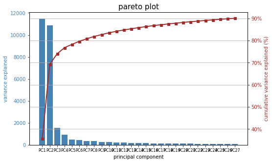

```python
X_train_pca, X_test_pca, y_train, y_test = func.preprocess_data(
    X, y, 65536, standard="True", pca="True", n_pc=0.9, show_plot="True")
```

# modeling standardize data

把標準化後的資料建模

## MLR

多元羅吉斯回歸 (Multinomial Logistic Regression)  
建模之後以 測試集 進行評估  
並且列出 4 種指標以供觀察

### default

```python
# MLR model & hyperparametersmodel
mlr_opts = dict(multi_class='auto', tol=1e-6, max_iter=int(150), verbose=1)
mlr_model = LogisticRegression(**mlr_opts)
mlr_model.fit(X_train_scaled, y_train)
# predict
y_pred_mlr = mlr_model.predict(X_test_scaled)
```

```python
# evaluation
mlr_eva = func.evaluate_model(y_test, y_pred_mlr)
# change to df
mlr_df = pd.DataFrame(list(mlr_eva.items()), columns=[
                      ["standard", "standard"], ["MLR", "MLR"], ['metric', 'value']])
mlr_df
```

|  | standard MLR metric | standard MLR value |
| --- | --- | --- |
| 0 | accuracy | 0.98 |
| 1 | precision | 0.98 |
| 2 | recall | 0.98 |
| 3 | F1-score | 0.97 |

### grid search

```python
# # search best parameter
# param_grid = {
#     'C': [0.5, 1],
#     'solver': ['newton-cg', 'lbfgs'],
#     'penalty': ['l1', 'l2']
# }

# # model
# mlr_opts = dict(multi_class='auto', tol=1e-6, max_iter=int(150), verbose=1)
# mlr_model = LogisticRegression(**mlr_opts)

# # grid search
# grid_search = GridSearchCV(mlr_model, param_grid, cv=5, verbose=2, n_jobs=-1)
# grid_search.fit(X_train_scaled, y_train)

# # print
# print("Best parameters found: ", grid_search.best_params_)

# # predict
# best_model = grid_search.best_estimator_
# y_pred_mlr_best = best_model.predict(X_test_scaled)
```

```python
# # evaluation
# mlr_eva_best = func.evaluate_model(y_test, y_pred_mlr_best)
# # change to df
# mlr_df_best = pd.DataFrame(list(mlr_eva_best.items()), columns=[
#                       ["standard", "standard"], ["MLR", "MLR"], ['metric', 'value']])
# mlr_df_best
```

### MLR conclusion

可以發現 default 的效果就已經近乎完美  
為了避免麻煩(運行時間過久 : > 30 min)  
因此使用 default 為最佳模型

## SVM

支援向量機 (Support Vector Machine)  
建模之後以 測試集 進行評估  
並且列出 4 種指標以供觀察

### default

```python
# SVM model & hyperparameter
svm_opts = dict(C=1, tol=1e-6, max_iter=int(1e6), verbose=1)
svm_model = SVC(kernel='linear', **svm_opts)
svm_model.fit(X_train_scaled, y_train)
# predict
y_pred_svm = svm_model.predict(X_test_scaled)
```

```
[LibSVM]
```

```python
# evaluation
svm_eva = func.evaluate_model(y_test, y_pred_svm)
# change to df
svm_df = pd.DataFrame(list(svm_eva.items()), columns=[
                      ["standard", "standard"], ["SVM", "SVM"], ['metric', 'value']])
svm_df
```

|  | standard SVM metric | standard SVM value |
| --- | --- | --- |
| 0 | accuracy | 0.94 |
| 1 | precision | 0.94 |
| 2 | recall | 0.94 |
| 3 | F1-score | 0.94 |

### grid search

```python
# # search best parameter
# param_grid = {
#     'C': [0.1, 1],
#     'kernel': ['linear', 'poly', 'rbf', 'sigmoid'],
#     'gamma': ['scale', 'auto'],
# }

# # model
# svm_opts = dict(tol=1e-6, max_iter=int(1e6))
# svm_model = SVC(**svm_opts)

# # grid search
# grid_search = GridSearchCV(svm_model, param_grid, cv=5, verbose=2, n_jobs=-1)
# grid_search.fit(X_train_scaled, y_train)

# # print
# print("Best parameters found: ", grid_search.best_params_)

# # predict
# best_model = grid_search.best_estimator_
# y_pred_svm_best = best_model.predict(X_test_scaled)
```

```python
# # evaluation
# svm_eva_best = func.evaluate_model(y_test, y_pred_svm_best)
# # change to df
# svm_df_best = pd.DataFrame(list(svm_eva_best.items()), columns=[
#                       ["standard", "standard"], ["SVM", "SVM"], ['metric', 'value']])
# svm_df_best
```

### SVM conclusion

可以發現 default 的效果就已經還算不錯  
為了避免麻煩(運行時間過久 : > 30 min)  
因此使用 default 為最佳模型

## NN--MLP

神經網路 (Neural Network) -- 多層感知機 (Multilayer perceptron)  
建模之後以 測試集 進行評估  
並且列出 4 種指標以供觀察

### default

```python
# NN-MLP model & hyperparameter
hidden_layers = (50, 100,120)
opts = dict(hidden_layer_sizes=hidden_layers, verbose=1,
            activation='relu', tol=1e-6, max_iter=int(1e6))
nn_mlp_model = MLPClassifier(solver='sgd', **opts)
nn_mlp_model.fit(X_train_scaled, y_train)
# predict
y_pred_nn_mlp = nn_mlp_model.predict(X_test_scaled)
```

```
Iteration 1, loss = 3.67098216
Iteration 2, loss = 3.52502260
Iteration 3, loss = 3.34179706
Iteration 4, loss = 3.13571983
Iteration 5, loss = 2.92585207
Iteration 6, loss = 2.72039130
Iteration 7, loss = 2.52689888
Iteration 8, loss = 2.34292591
Iteration 9, loss = 2.16556291
Iteration 10, loss = 2.00070370
Iteration 11, loss = 1.85052644
Iteration 12, loss = 1.71119978
Iteration 13, loss = 1.58328276
Iteration 14, loss = 1.46885046
Iteration 15, loss = 1.36395925
Iteration 16, loss = 1.26749571
Iteration 17, loss = 1.17914078
Iteration 18, loss = 1.09276264
Iteration 19, loss = 1.00920745
Iteration 20, loss = 0.93529511
Iteration 21, loss = 0.86205718
Iteration 22, loss = 0.79306246
Iteration 23, loss = 0.73397272
Iteration 24, loss = 0.68184504
Iteration 25, loss = 0.63086239
Iteration 26, loss = 0.58285416
Iteration 27, loss = 0.54054672
Iteration 28, loss = 0.50000067
Iteration 29, loss = 0.46471340
Iteration 30, loss = 0.43516379
Iteration 31, loss = 0.40513854
Iteration 32, loss = 0.37972701
Iteration 33, loss = 0.35299533
Iteration 34, loss = 0.33360643
Iteration 35, loss = 0.31105176
Iteration 36, loss = 0.29716427
Iteration 37, loss = 0.28018951
Iteration 38, loss = 0.26761438
Iteration 39, loss = 0.25378127
Iteration 40, loss = 0.23593215
```

[output cut: 265 more lines]

```
Iteration 306, loss = 0.01612595
Iteration 307, loss = 0.01630952
Iteration 308, loss = 0.01526144
Iteration 309, loss = 0.01621045
Iteration 310, loss = 0.01608111
Iteration 311, loss = 0.01616134
Iteration 312, loss = 0.01565347
Iteration 313, loss = 0.01654360
Iteration 314, loss = 0.01782763
Iteration 315, loss = 0.01603573
Iteration 316, loss = 0.01644445
Iteration 317, loss = 0.01704883
Iteration 318, loss = 0.01543136
Iteration 319, loss = 0.01561605
Training loss did not improve more than tol=0.000001 for 10 consecutive epochs. Stopping.
```

```python
# evaluation
nn_mlp_eva = func.evaluate_model(y_test, y_pred_nn_mlp)
# change to df
nn_mlp_df = pd.DataFrame(list(nn_mlp_eva.items()), columns=[
                         ["standard", "standard"], ["NN_MLP", "NN_MLP"], ['metric', 'value']])
nn_mlp_df
```

|  | standard NN_MLP metric | standard NN_MLP value |
| --- | --- | --- |
| 0 | accuracy | 0.96 |
| 1 | precision | 0.96 |
| 2 | recall | 0.96 |
| 3 | F1-score | 0.96 |

### grid search

```python
# # search best parameter
# param_grid = {
#     'hidden_layer_sizes': [(50, 100)],
#     'activation': ['logistic', 'relu'],
#     'solver': ['lbfgs', 'sgd', 'adam'],
# }

# # model
# opts = dict(verbose=1, tol=1e-6, max_iter=int(1e6))
# nn_mlp_model = MLPClassifier(**opts)

# # grid search
# grid_search = GridSearchCV(nn_mlp_model, param_grid, cv=5, verbose=2, n_jobs=-1)
# grid_search.fit(X_train_scaled, y_train)

# # print
# print("Best parameters found: ", grid_search.best_params_)

# # predict
# best_model = grid_search.best_estimator_
# y_pred_nn_mlp_best = best_model.predict(X_test_scaled)
```

```python
# # evaluation
# nn_mlp_eva_best = func.evaluate_model(y_test, y_pred_nn_mlp_best)
# # change to df
# nn_mlp_df_best = pd.DataFrame(list(nn_mlp_eva_best.items()), columns=[
#                          ["standard", "standard"], ["NN_MLP", "NN_MLP"], ['metric', 'value']])
# nn_mlp_df_best
```

### NN--MLP conclusion

可以發現 default 的效果就已經還算不錯  
為了避免麻煩(運行時間過久 : > 30 min)  
因此使用 default 為最佳模型

## NN--SEQ

神經網路 (Neural Network) -- 簡單的線性堆疊模型  
一層一層的建立神經網路  
接著列出現在構建的網路長甚麼樣子  
建模之後以 測試集 進行評估  
並且列出 4 種指標以供觀察

```python
# change 1~3 to 0~2
y_train_nn = y_train-1
y_test_nn = y_test-1

# model
nn_seq_model = Sequential()
nn_seq_model.add(Dense(64, activation='relu',
                 input_shape=(X_train_scaled.shape[1],)))
nn_seq_model.add(Dense(40, activation='relu'))
nn_seq_model.add(Dropout(0.2))
nn_seq_model.add(Dense(32, activation='relu'))
# avoid overfitting
# nn_seq_model.add(Dropout(0.2))
nn_seq_model.add(Dense(38, activation='softmax'))

# compile
# set learning rate
optimizer = Adam(learning_rate=0.001)
nn_seq_model.compile(optimizer=optimizer,
                     loss='sparse_categorical_crossentropy',
                     metrics=['accuracy'])

# check model
nn_seq_model.summary()
```

```
WARNING:tensorflow:From C:\Users\ACER\anaconda3\lib\site-packages\keras\src\backend.py:873: The name tf.get_default_graph is deprecated. Please use tf.compat.v1.get_default_graph instead.

Model: "sequential"
_________________________________________________________________
 Layer (type)                Output Shape              Param #
=================================================================
 dense (Dense)               (None, 64)                2064448

 dense_1 (Dense)             (None, 40)                2600

 dropout (Dropout)           (None, 40)                0

 dense_2 (Dense)             (None, 32)                1312

 dense_3 (Dense)             (None, 38)                1254

=================================================================
Total params: 2069614 (7.89 MB)
Trainable params: 2069614 (7.89 MB)
Non-trainable params: 0 (0.00 Byte)
_________________________________________________________________
```

```python
# fit model
history = nn_seq_model.fit(X_train_scaled, y_train_nn,
                           epochs=150, validation_split=0.2, verbose=1)
```

[output not shown]

```python
# evaluation
test_loss, test_accuracy = nn_seq_model.evaluate(
    X_test_scaled, y_test_nn, verbose=0)
y_pred_prob = nn_seq_model.predict(X_test_scaled, verbose=0)
y_pred_nn_seq = np.argmax(y_pred_prob, axis=1)
print("loss :", test_loss)
print("accuracy :", test_accuracy)
```

```
loss : 0.385423868894577
accuracy : 0.9066389799118042
```

```python
# evaluation
nn_seq_eva = func.evaluate_model(y_test_nn, y_pred_nn_seq)
# change to df
nn_seq_df = pd.DataFrame(list(nn_seq_eva.items()), columns=[
                         ["standard", "standard"], ["NN_SEQ", "NN_SEQ"], ['metric', 'value']])
nn_seq_df
```

|  | standard NN_SEQ metric | standard NN_SEQ value |
| --- | --- | --- |
| 0 | accuracy | 0.91 |
| 1 | precision | 0.92 |
| 2 | recall | 0.91 |
| 3 | F1-score | 0.91 |

## compare evaluation of standardize data

把上述所有的評估指標組合一起觀察

```python
# combine df together
mlr_df_copy = mlr_df.copy()
svm_df_copy = svm_df.copy()
nn_mlp_df_copy = nn_mlp_df.copy()
nn_seq_df_copy = nn_seq_df.copy()
# del same col
svm_df_copy.drop(("standard", "SVM", "metric"), axis=1, inplace=True)
nn_mlp_df_copy.drop(("standard", "NN_MLP", "metric"), axis=1, inplace=True)
nn_seq_df_copy.drop(("standard", "NN_SEQ", "metric"), axis=1, inplace=True)

# combine
final_df_standard = pd.concat(
    [mlr_df_copy, svm_df_copy, nn_mlp_df_copy, nn_seq_df_copy], axis=1)
# set "metric" to index
final_df_standard.set_index(("standard", "MLR", "metric"), inplace=True)
final_df_standard = final_df_standard.rename_axis("metric")

# show
final_df_standard
```

| metric | standard MLR value | standard SVM value | standard NN_MLP value | standard NN_SEQ value |
| --- | --- | --- | --- | --- |
| accuracy | 0.98 | 0.94 | 0.96 | 0.91 |
| precision | 0.98 | 0.94 | 0.96 | 0.92 |
| recall | 0.98 | 0.94 | 0.96 | 0.91 |
| F1-score | 0.97 | 0.94 | 0.96 | 0.91 |

## model of standardize data conclusion

可以看出總體來說 MLR 模型的表現是最好的

# modeling pca data

把 PCA 後的資料建模

## MLR

多元羅吉斯回歸 (Multinomial Logistic Regression)  
建模之後以 測試集 進行評估  
並且列出 4 種指標以供觀察

### default

```python
# MLR model & hyperparametersmodel
mlr_opts = dict(multi_class='auto',C = 0.1, tol=1e-6, max_iter=int(1e6), verbose=1)
mlr_model = LogisticRegression(**mlr_opts)
mlr_model.fit(X_train_pca, y_train)
# predict
y_pred_mlr = mlr_model.predict(X_test_pca)
```

```python
# evaluation
mlr_eva = func.evaluate_model(y_test, y_pred_mlr)
# change to df
mlr_df = pd.DataFrame(list(mlr_eva.items()), columns=[
                      ["PCA", "PCA"], ["MLR", "MLR"], ['metric', 'value']])
mlr_df
```

|  | PCA MLR metric | PCA MLR value |
| --- | --- | --- |
| 0 | accuracy | 0.88 |
| 1 | precision | 0.89 |
| 2 | recall | 0.88 |
| 3 | F1-score | 0.88 |

### grid search

```python
# search best parameter
param_grid = {
    'C': [0.01, 0.1, 1],
    'solver': ['newton-cg', 'lbfgs'],
    'penalty': ['l1', 'l2']
}

# model
mlr_opts = dict(multi_class='auto', tol=1e-6, max_iter=int(1e6), verbose=1)
mlr_model = LogisticRegression(**mlr_opts)

# grid search
grid_search = GridSearchCV(mlr_model, param_grid, cv=5, verbose=2, n_jobs=-1)
grid_search.fit(X_train_pca, y_train)

# print
print("Best parameters found: ", grid_search.best_params_)

# predict
best_model = grid_search.best_estimator_
y_pred_mlr_best = best_model.predict(X_test_pca)
```

```
Fitting 5 folds for each of 12 candidates, totalling 60 fits
Best parameters found:  {'C': 0.1, 'penalty': 'l2', 'solver': 'lbfgs'}
```

```python
# evaluation
mlr_eva_best = func.evaluate_model(y_test, y_pred_mlr_best)
# change to df
mlr_df_best = pd.DataFrame(list(mlr_eva_best.items()), columns=[
                      ["PCA", "PCA"], ["MLR", "MLR"], ['metric', 'value']])
mlr_df_best
```

|  | PCA MLR metric | PCA MLR value |
| --- | --- | --- |
| 0 | accuracy | 0.88 |
| 1 | precision | 0.89 |
| 2 | recall | 0.88 |
| 3 | F1-score | 0.88 |

### MLR conclusion

可以發現 2個的結果相同  
為了避免麻煩  
因此使用 default 為最佳模型

## SVM

支援向量機 (Support Vector Machine)  
建模之後以 測試集 進行評估  
並且列出 4 種指標以供觀察

### default

```python
# SVM model & hyperparameter
svm_opts = dict(C=1, tol=1e-6, max_iter=int(1e6))
svm_model = SVC(kernel='linear', **svm_opts)
svm_model.fit(X_train_pca, y_train)
# predict
y_pred_svm = svm_model.predict(X_test_pca)
```

```python
# evaluation
svm_eva = func.evaluate_model(y_test, y_pred_svm)
# change to df
svm_df = pd.DataFrame(list(svm_eva.items()), columns=[
                      ["PCA", "PCA"], ["SVM", "SVM"], ['metric', 'value']])
svm_df
```

|  | PCA SVM metric | PCA SVM value |
| --- | --- | --- |
| 0 | accuracy | 0.89 |
| 1 | precision | 0.90 |
| 2 | recall | 0.89 |
| 3 | F1-score | 0.89 |

### grid search

```python
# search best parameter
param_grid = {
    'C': [0.05, 0.08, 0.1, 1],
    'kernel': ['linear', 'poly', 'rbf', 'sigmoid'],
    'gamma': ['scale', 'auto'],
}

# model
svm_opts = dict(tol=1e-6, max_iter=int(1e6))
svm_model = SVC(**svm_opts)

# grid search
grid_search = GridSearchCV(svm_model, param_grid, cv=5, verbose=2, n_jobs=-1)
grid_search.fit(X_train_pca, y_train)

# print
print("Best parameters found: ", grid_search.best_params_)

# predict
best_model = grid_search.best_estimator_
y_pred_svm_best = best_model.predict(X_test_pca)
```

```
Fitting 5 folds for each of 32 candidates, totalling 160 fits
Best parameters found:  {'C': 0.05, 'gamma': 'scale', 'kernel': 'linear'}
```

```python
# evaluation
svm_eva_best = func.evaluate_model(y_test, y_pred_svm_best)
# change to df
svm_df_best = pd.DataFrame(list(svm_eva_best.items()), columns=[
                      ["PCA", "PCA"], ["SVM", "SVM"], ['metric', 'value']])
svm_df_best
```

|  | PCA SVM metric | PCA SVM value |
| --- | --- | --- |
| 0 | accuracy | 0.90 |
| 1 | precision | 0.91 |
| 2 | recall | 0.90 |
| 3 | F1-score | 0.90 |

### SVM conclusion

可以發現 best 的結果就已經是最好的  
因此使用 best 為最佳模型

## NN--MLP

神經網路 (Neural Network) -- 多層感知機 (Multilayer perceptron)  
建模之後以 測試集 進行評估  
並且列出 4 種指標以供觀察

### default

```python
# NN-MLP model & hyperparameter
hidden_layers = (50, 100,120)
opts = dict(hidden_layer_sizes=hidden_layers, verbose=1,
            activation='relu', tol=1e-6, max_iter=int(1e6))
nn_mlp_model = MLPClassifier(solver='adam', **opts)
nn_mlp_model.fit(X_train_pca, y_train)
# predict
y_pred_nn_mlp = nn_mlp_model.predict(X_test_pca)
```

```
Iteration 1, loss = 12.16149277
Iteration 2, loss = 6.17901377
Iteration 3, loss = 4.39708449
Iteration 4, loss = 3.46573837
Iteration 5, loss = 2.92055004
Iteration 6, loss = 2.51078475
Iteration 7, loss = 2.19753477
Iteration 8, loss = 1.93325700
Iteration 9, loss = 1.70736621
Iteration 10, loss = 1.51792539
Iteration 11, loss = 1.35127812
Iteration 12, loss = 1.21933759
Iteration 13, loss = 1.09234195
Iteration 14, loss = 0.98303504
Iteration 15, loss = 0.89586792
Iteration 16, loss = 0.81347210
Iteration 17, loss = 0.75346302
Iteration 18, loss = 0.68941466
Iteration 19, loss = 0.63371682
Iteration 20, loss = 0.57687211
Iteration 21, loss = 0.53703192
Iteration 22, loss = 0.49643657
Iteration 23, loss = 0.46496089
Iteration 24, loss = 0.42824359
Iteration 25, loss = 0.40637853
Iteration 26, loss = 0.38301566
Iteration 27, loss = 0.35493325
Iteration 28, loss = 0.33589812
Iteration 29, loss = 0.31847786
Iteration 30, loss = 0.29794830
Iteration 31, loss = 0.28961391
Iteration 32, loss = 0.27111687
Iteration 33, loss = 0.25650103
Iteration 34, loss = 0.24591844
Iteration 35, loss = 0.23185002
Iteration 36, loss = 0.21560216
Iteration 37, loss = 0.20762459
Iteration 38, loss = 0.21088000
Iteration 39, loss = 0.18700884
Iteration 40, loss = 0.18254093
```

[output cut: 82 more lines]

```
Iteration 123, loss = 0.02291516
Iteration 124, loss = 0.02638059
Iteration 125, loss = 0.02081841
Iteration 126, loss = 0.02765348
Iteration 127, loss = 0.03231634
Iteration 128, loss = 0.02556221
Iteration 129, loss = 0.02784723
Iteration 130, loss = 0.02349143
Iteration 131, loss = 0.02694333
Iteration 132, loss = 0.02437332
Iteration 133, loss = 0.02139313
Iteration 134, loss = 0.02291753
Iteration 135, loss = 0.02167384
Iteration 136, loss = 0.02096662
Training loss did not improve more than tol=0.000001 for 10 consecutive epochs. Stopping.
```

```python
# evaluation
nn_mlp_eva = func.evaluate_model(y_test, y_pred_nn_mlp)
# change to df
nn_mlp_df = pd.DataFrame(list(nn_mlp_eva.items()), columns=[
                         ["PCA", "PCA"], ["NN_MLP", "NN_MLP"], ['metric', 'value']])
nn_mlp_df
```

|  | PCA NN_MLP metric | PCA NN_MLP value |
| --- | --- | --- |
| 0 | accuracy | 0.87 |
| 1 | precision | 0.88 |
| 2 | recall | 0.87 |
| 3 | F1-score | 0.87 |

### grid search

```python
# search best parameter
param_grid = {
    'hidden_layer_sizes': [(50, 100,120)],
    'activation': ['logistic', 'relu'],
    'solver': ['lbfgs', 'sgd', 'adam'],
}

# model
opts = dict(verbose=1, tol=1e-6, max_iter=int(1e5))
nn_mlp_model = MLPClassifier(**opts)

# grid search
grid_search = GridSearchCV(nn_mlp_model, param_grid, cv=5, verbose=2, n_jobs=-1)
grid_search.fit(X_train_pca, y_train)

# print
print("Best parameters found: ", grid_search.best_params_)

# predict
best_model = grid_search.best_estimator_
y_pred_nn_mlp_best = best_model.predict(X_test_pca)
```

```
Fitting 5 folds for each of 6 candidates, totalling 30 fits
Best parameters found:  {'activation': 'relu', 'hidden_layer_sizes': (50, 100, 120), 'solver': 'lbfgs'}
```

```python
# evaluation
nn_mlp_eva_best = func.evaluate_model(y_test, y_pred_nn_mlp_best)
# change to df
nn_mlp_df_best = pd.DataFrame(list(nn_mlp_eva_best.items()), columns=[
                         ["PCA", "PCA"], ["NN_MLP", "NN_MLP"], ['metric', 'value']])
nn_mlp_df_best
```

|  | PCA NN_MLP metric | PCA NN_MLP value |
| --- | --- | --- |
| 0 | accuracy | 0.88 |
| 1 | precision | 0.89 |
| 2 | recall | 0.88 |
| 3 | F1-score | 0.88 |

## NN--SEQ

```python
# change 1~3 to 0~2
y_train_nn = y_train-1
y_test_nn = y_test-1

# model
nn_seq_model = Sequential()
nn_seq_model.add(Dense(64, activation='relu',
                 input_shape=(X_train_pca.shape[1],)))
nn_seq_model.add(Dense(32, activation='relu'))
# avoid overfitting
nn_seq_model.add(Dropout(0.2))
nn_seq_model.add(Dense(38, activation='softmax'))

# compile
# set learning rate
optimizer = Adam(learning_rate=0.001)
nn_seq_model.compile(optimizer=optimizer,
                     loss='sparse_categorical_crossentropy',
                     metrics=['accuracy'])

# check model
nn_seq_model.summary()
```

```
Model: "sequential_1"
_________________________________________________________________
 Layer (type)                Output Shape              Param #
=================================================================
 dense_4 (Dense)             (None, 64)                1792

 dense_5 (Dense)             (None, 32)                2080

 dropout_1 (Dropout)         (None, 32)                0

 dense_6 (Dense)             (None, 38)                1254

=================================================================
Total params: 5126 (20.02 KB)
Trainable params: 5126 (20.02 KB)
Non-trainable params: 0 (0.00 Byte)
_________________________________________________________________
```

```python
# fit model
history = nn_seq_model.fit(X_train_pca, y_train_nn,
                           epochs=250, validation_split=0.2, verbose=1)
```

[output not shown]

```python
# evaluation
test_loss, test_accuracy = nn_seq_model.evaluate(
    X_test_pca, y_test_nn, verbose=0)
y_pred_prob = nn_seq_model.predict(X_test_pca, verbose=0)
y_pred_nn_seq = np.argmax(y_pred_prob, axis=1)
print("loss :", test_loss)
print("accuracy :", test_accuracy)
```

```
loss : 0.5134116411209106
accuracy : 0.8962655663490295
```

```python
# evaluation
nn_seq_eva = func.evaluate_model(y_test_nn, y_pred_nn_seq)
# change to df
nn_seq_df = pd.DataFrame(list(nn_seq_eva.items()), columns=[
                         ["PCA", "PCA"], ["NN_SEQ", "NN_SEQ"], ['metric', 'value']])
nn_seq_df
```

|  | PCA NN_SEQ metric | PCA NN_SEQ value |
| --- | --- | --- |
| 0 | accuracy | 0.9 |
| 1 | precision | 0.9 |
| 2 | recall | 0.9 |
| 3 | F1-score | 0.9 |

## compare evaluation of pca data

```python
# combine df together
mlr_df_copy = mlr_df.copy()
svm_df_best_copy = svm_df_best.copy()
nn_mlp_df_copy = nn_mlp_df.copy()
nn_seq_df_copy = nn_seq_df.copy()
# del same col
svm_df_best_copy.drop(("PCA", "SVM", "metric"), axis=1, inplace=True)
nn_mlp_df_copy.drop(("PCA", "NN_MLP", "metric"), axis=1, inplace=True)
nn_seq_df_copy.drop(("PCA", "NN_SEQ", "metric"), axis=1, inplace=True)

# combine
final_df_pca = pd.concat(
    [mlr_df_copy, svm_df_best_copy, nn_mlp_df_copy, nn_seq_df_copy], axis=1)
# set "metric" to index
final_df_pca.set_index(("PCA", "MLR", "metric"), inplace=True)
final_df_pca = final_df_pca.rename_axis("metric")

# show
final_df_pca
```

| metric | PCA MLR value | PCA SVM value | PCA NN_MLP value | PCA NN_SEQ value |
| --- | --- | --- | --- | --- |
| accuracy | 0.88 | 0.90 | 0.87 | 0.9 |
| precision | 0.89 | 0.91 | 0.88 | 0.9 |
| recall | 0.88 | 0.90 | 0.87 | 0.9 |
| F1-score | 0.88 | 0.90 | 0.87 | 0.9 |

## model of pca data conclusion

可以看出總體來說 SVM、NN_SEQ 模型的表現是最好的  
雖然得到的分數與剩下的沒有差距太大  
不過他們所運行時間並不會太長

# final conclusion

把上述所有的評估指標組合一起觀察

```python
final_df = pd.concat(
    [final_df_standard, final_df_pca], axis=1)
final_df
```

| metric | standard MLR value | standard SVM value | standard NN_MLP value | standard NN_SEQ value | PCA MLR value | PCA SVM value | PCA NN_MLP value | PCA NN_SEQ value |
| --- | --- | --- | --- | --- | --- | --- | --- | --- |
| accuracy | 0.98 | 0.94 | 0.96 | 0.91 | 0.88 | 0.90 | 0.87 | 0.9 |
| precision | 0.98 | 0.94 | 0.96 | 0.92 | 0.89 | 0.91 | 0.88 | 0.9 |
| recall | 0.98 | 0.94 | 0.96 | 0.91 | 0.88 | 0.90 | 0.87 | 0.9 |
| F1-score | 0.97 | 0.94 | 0.96 | 0.91 | 0.88 | 0.90 | 0.87 | 0.9 |

可以發現到其實資料集進行標準化得到的評估指標相較於 PCA 優異了一點  
有可能是因為 PCA 時把一些特徵忽略掉所導致的  
但如果以運行時間來觀察的話  
能夠發現經過 PCA 後的資料在 fit 模型時花費的時間比較短